# IP part 1 & 2 _ Carrerfour Analysis EDA and Feature Selection

Ann Mberi

7/20/2021

**1. Business Understanding 1 a.) Defining the Question You are a Data analyst at Carrefour Kenya and are currently undertaking a project that will inform the marketing department on the most relevant marketing strategies that will result in the highest no. of sales (total price including tax). Hence making an analysis to Customer Data from a the supermarket and implement dimensionality reduction. 2. Defining the Metrics of Success The success of this analysis will occur when we analysis the customer data to understand it fully and later implementing the appropriate dimensionality reduction techniques. 3. Context Dimensionality reduction is the process of reducing the number of random variables under review, by getting a set of principal variables. It can be divided into feature selection and feature extraction and is important for the visualization of features while it also helps deal with multicollinearity of the features. 4. Experimental Design We will define the question, the metric of success, context and experimental design taken. This will be followed by reading and exploring the dataset and its appropriateness of the available data to answer the given question. This will be followed by cleaning the data off outliers, anomalies and null values from missing data, perfom an exploratory data analysis after which we will Implement feature extraction and feature selection,record our observations and provide a conclusion and reccomendation. 1 5. Data Relevance Our data is very relevant to our research question.

**# 1. Importing the Libraries**

```r
library("data.table")
```

```r
library("plyr")
```

```r
library("dplyr")
```

```r
library("ggplot2")
```

```r
library("tidyverse")
library("tidyr")
library("lubridate")
```

```r
library("ggcorrplot")
library("ggplot2")
library("corrplot")
library("moments")
library("xtable")
library("countrycode")
library("class")
library("rpart")
library("rpart.plot")
library("mlbench")
library("e1071")
library("rpart")
library("caret")
library("ranger")
library("kernlab")
install.packages("devtools", repo="http://cran.us.r-project.org")
library(devtools)
install_github("vqv/ggbiplot")
```

```
## Skipping install of 'ggbiplot' from a github remote, the SHA1 (7325e880) has not changed since last install.
##   Use `force = TRUE` to force installation
```

```r
library("devtools")
```

```r
library(ggbiplot)
library("ISLR")
library("devtools")
```

**# 2. Loading the Dataset.**

```r
cf_df <- read.csv(url("http://bit.ly/CarreFourDataset"))
```

**# 3. PREVIEWING THE DATA**

```r
head(cf_df) #we preview  the first 6 rows in our dataset
```

```
##    Invoice.ID Branch Customer.type Gender           Product.line Unit.price
## 1 750-67-8428      A        Member Female      Health and beauty      74.69
## 2 226-31-3081      C        Normal Female Electronic accessories      15.28
## 3 631-41-3108      A        Normal   Male     Home and lifestyle      46.33
## 4 123-19-1176      A        Member   Male      Health and beauty      58.22
## 5 373-73-7910      A        Normal   Male      Sports and travel      86.31
## 6 699-14-3026      C        Normal   Male Electronic accessories      85.39
##   Quantity     Tax      Date  Time     Payment   cogs gross.margin.percentage
## 1        7 26.1415  1/5/2019 13:08     Ewallet 522.83                4.761905
## 2        5  3.8200  3/8/2019 10:29        Cash  76.40                4.761905
## 3        7 16.2155  3/3/2019 13:23 Credit card 324.31                4.761905
## 4        8 23.2880 1/27/2019 20:33     Ewallet 465.76                4.761905
## 5        7 30.2085  2/8/2019 10:37     Ewallet 604.17                4.761905
## 6        7 29.8865 3/25/2019 18:30     Ewallet 597.73                4.761905
##   gross.income Rating    Total
## 1      26.1415    9.1 548.9715
## 2       3.8200    9.6  80.2200
## 3      16.2155    7.4 340.5255
## 4      23.2880    8.4 489.0480
## 5      30.2085    5.3 634.3785
## 6      29.8865    4.1 627.6165
```

```r
tail(cf_df) # We preview the last 6 rows of our dataset
```

```
##       Invoice.ID Branch Customer.type Gender           Product.line Unit.price
## 995  652-49-6720      C        Member Female Electronic accessories      60.95
## 996  233-67-5758      C        Normal   Male      Health and beauty      40.35
## 997  303-96-2227      B        Normal Female     Home and lifestyle      97.38
## 998  727-02-1313      A        Member   Male     Food and beverages      31.84
## 999  347-56-2442      A        Normal   Male     Home and lifestyle      65.82
## 1000 849-09-3807      A        Member Female    Fashion accessories      88.34
##      Quantity     Tax      Date  Time Payment   cogs gross.margin.percentage
## 995         1  3.0475 2/18/2019 11:40 Ewallet  60.95                4.761905
## 996         1  2.0175 1/29/2019 13:46 Ewallet  40.35                4.761905
## 997        10 48.6900  3/2/2019 17:16 Ewallet 973.80                4.761905
## 998         1  1.5920  2/9/2019 13:22    Cash  31.84                4.761905
## 999         1  3.2910 2/22/2019 15:33    Cash  65.82                4.761905
## 1000        7 30.9190 2/18/2019 13:28    Cash 618.38                4.761905
##      gross.income Rating     Total
## 995        3.0475    5.9   63.9975
## 996        2.0175    6.2   42.3675
## 997       48.6900    4.4 1022.4900
## 998        1.5920    7.7   33.4320
## 999        3.2910    4.1   69.1110
## 1000      30.9190    6.6  649.2990
```

#### Data Dimensions

```r
dim(cf_df)
```

```
## [1] 1000   16
```

#### Data Structure

```r
str(cf_df)
```

```
## 'data.frame':    1000 obs. of  16 variables:
##  $ Invoice.ID             : chr  "750-67-8428" "226-31-3081" "631-41-3108" "123-19-1176" ...
##  $ Branch                 : chr  "A" "C" "A" "A" ...
##  $ Customer.type          : chr  "Member" "Normal" "Normal" "Member" ...
##  $ Gender                 : chr  "Female" "Female" "Male" "Male" ...
##  $ Product.line           : chr  "Health and beauty" "Electronic accessories" "Home and lifestyle" "Health and beauty" ...
##  $ Unit.price             : num  74.7 15.3 46.3 58.2 86.3 ...
##  $ Quantity               : int  7 5 7 8 7 7 6 10 2 3 ...
##  $ Tax                    : num  26.14 3.82 16.22 23.29 30.21 ...
##  $ Date                   : chr  "1/5/2019" "3/8/2019" "3/3/2019" "1/27/2019" ...
##  $ Time                   : chr  "13:08" "10:29" "13:23" "20:33" ...
##  $ Payment                : chr  "Ewallet" "Cash" "Credit card" "Ewallet" ...
##  $ cogs                   : num  522.8 76.4 324.3 465.8 604.2 ...
##  $ gross.margin.percentage: num  4.76 4.76 4.76 4.76 4.76 ...
##  $ gross.income           : num  26.14 3.82 16.22 23.29 30.21 ...
##  $ Rating                 : num  9.1 9.6 7.4 8.4 5.3 4.1 5.8 8 7.2 5.9 ...
##  $ Total                  : num  549 80.2 340.5 489 634.4 ...
```

**# 4. DATA PREPARATION**

### a) Uniformity

# Lets check the column names

```r
colnames(cf_df)
```

```
##  [1] "Invoice.ID"              "Branch"
##  [3] "Customer.type"           "Gender"
##  [5] "Product.line"            "Unit.price"
##  [7] "Quantity"                "Tax"
##  [9] "Date"                    "Time"
## [11] "Payment"                 "cogs"
## [13] "gross.margin.percentage" "gross.income"
## [15] "Rating"                  "Total"
```

## Lets’s rename some columns

```r
names(cf_df)[1]<- "Invoice_ID"
names(cf_df)[3]<- "Customer_type"
names(cf_df)[5]<- "Product_line"
names(cf_df)[6]<- "Unit_price"
names(cf_df)[14]<- "Gross_income"
```

## Lets run the columns in our dataset to preview if the changes have been implemented for uniformality purposes

```r
colnames(cf_df)
```

```
##  [1] "Invoice_ID"              "Branch"
##  [3] "Customer_type"           "Gender"
##  [5] "Product_line"            "Unit_price"
##  [7] "Quantity"                "Tax"
##  [9] "Date"                    "Time"
## [11] "Payment"                 "cogs"
## [13] "gross.margin.percentage" "Gross_income"
## [15] "Rating"                  "Total"
```

# Lets check the length of unique values in each column

```r
lapply(cf_df, function (x) {length(unique(x))})
```

```
## $Invoice_ID
## [1] 1000
##
## $Branch
## [1] 3
##
## $Customer_type
## [1] 2
##
## $Gender
## [1] 2
##
## $Product_line
## [1] 6
##
## $Unit_price
## [1] 943
##
## $Quantity
## [1] 10
##
## $Tax
## [1] 990
##
## $Date
## [1] 89
##
## $Time
## [1] 506
##
## $Payment
## [1] 3
##
## $cogs
## [1] 990
##
## $gross.margin.percentage
## [1] 1
##
## $Gross_income
## [1] 990
##
## $Rating
## [1] 61
##
## $Total
## [1] 990
```

## Lets check if the tax and gross income columns are duplicated

```r
unique(cf_df$Tax == cf_df$Gross_income)
```

```
## [1] TRUE
```

## Its confirmed they are duplicated, we now drop the gross margin percentage

```r
cf_df <- cf_df[, -8]
cf_df <- cf_df[, -12]
```

```r
dim(cf_df)
```

```
## [1] 1000   14
```

The gross income percentage has one unique variable making it not important in our analysis

### b) Completeness

## Lets check for missing values

```r
colSums(is.na(cf_df))
```

```
##    Invoice_ID        Branch Customer_type        Gender  Product_line
##             0             0             0             0             0
##    Unit_price      Quantity          Date          Time       Payment
##             0             0             0             0             0
##          cogs  Gross_income        Rating         Total
##             0             0             0             0
```

## Checking for duplicated values

```r
duplicates <- cf_df[duplicated(cf_df),]
duplicates
```

```
##  [1] Invoice_ID    Branch        Customer_type Gender        Product_line
##  [6] Unit_price    Quantity      Date          Time          Payment
## [11] cogs          Gross_income  Rating        Total
## <0 rows> (or 0-length row.names)
```

## checking for outliers

## We plot boxplots for all numerical variables

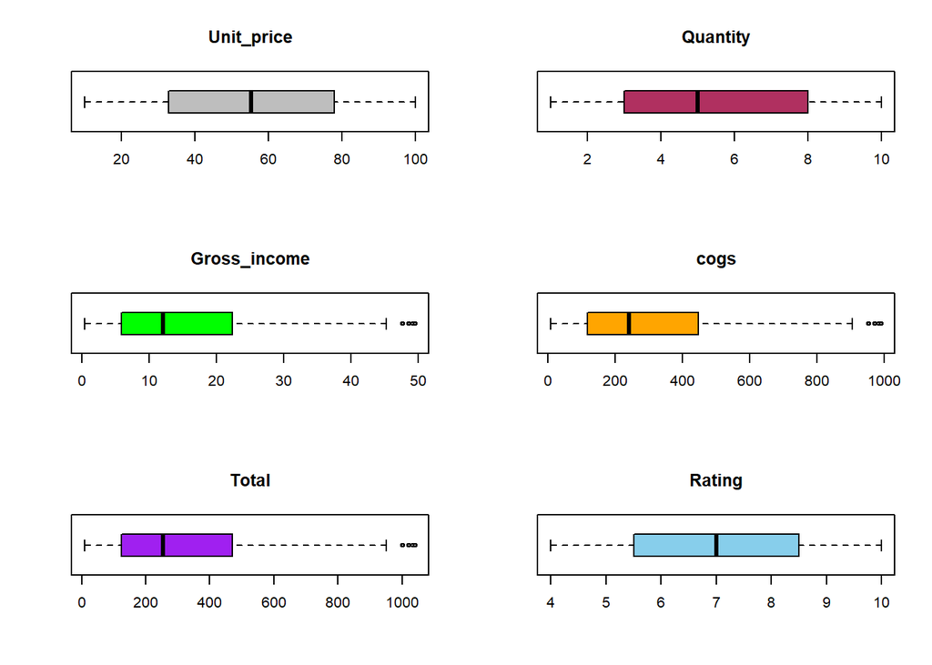

```r
par(mfrow=c(3,2))
boxplot((cf_df$"Unit_price"), horizontal = TRUE, col = "grey", main = "Unit_price")
boxplot((cf_df$"Quantity"), horizontal = TRUE, col = "maroon", main = "Quantity")
boxplot((cf_df$"Gross"), horizontal = TRUE, col = "green", main = "Gross_income")
boxplot((cf_df$"cogs"), horizontal = TRUE, col = "orange", main = "cogs")
boxplot((cf_df$"Total"), horizontal = TRUE, col = "purple", main = "Total")
boxplot((cf_df$"Rating"), horizontal = TRUE, col = "skyblue", main = "Rating")
```

# We have a few outliers but they will not be removed, they may have vital information

**# 5. Exploratory Data Analysis**

**Univariate Analysis**

## We now check our data summary

```r
summary(cf_df)
```

```
##   Invoice_ID           Branch          Customer_type         Gender
##  Length:1000        Length:1000        Length:1000        Length:1000
##  Class :character   Class :character   Class :character   Class :character
##  Mode  :character   Mode  :character   Mode  :character   Mode  :character
##
##
##
##  Product_line         Unit_price       Quantity         Date
##  Length:1000        Min.   :10.08   Min.   : 1.00   Length:1000
##  Class :character   1st Qu.:32.88   1st Qu.: 3.00   Class :character
##  Mode  :character   Median :55.23   Median : 5.00   Mode  :character
##                     Mean   :55.67   Mean   : 5.51
##                     3rd Qu.:77.94   3rd Qu.: 8.00
##                     Max.   :99.96   Max.   :10.00
##      Time             Payment               cogs         Gross_income
##  Length:1000        Length:1000        Min.   : 10.17   Min.   : 0.5085
##  Class :character   Class :character   1st Qu.:118.50   1st Qu.: 5.9249
##  Mode  :character   Mode  :character   Median :241.76   Median :12.0880
##                                        Mean   :307.59   Mean   :15.3794
##                                        3rd Qu.:448.90   3rd Qu.:22.4453
##                                        Max.   :993.00   Max.   :49.6500
##      Rating           Total
##  Min.   : 4.000   Min.   :  10.68
##  1st Qu.: 5.500   1st Qu.: 124.42
##  Median : 7.000   Median : 253.85
##  Mean   : 6.973   Mean   : 322.97
##  3rd Qu.: 8.500   3rd Qu.: 471.35
##  Max.   :10.000   Max.   :1042.65
```

## Measures of Central Tendancy and Dispersion

##Central Tendancy - Mode, Mean and Median  
### Unit Price ### Mean

```r
mean(cf_df$Unit_price)
```

```
## [1] 55.67213
```

### Mode

### We first a mose function. This is because R has no built in function

```r
getmode <- function(v) {
uniqv <- unique(v)
uniqv[which.max(tabulate(match(v, uniqv)))]
}
```

```r
mode.up <- getmode(cf_df$Unit_price)
mode.up
```

```
## [1] 83.77
```

### Median

```r
median(cf_df$Unit_price)
```

```
## [1] 55.23
```

### Gross_Income

### Mean

```r
mean(cf_df$Gross_income)
```

```
## [1] 15.37937
```

###Mode

```r
mode.gi <- getmode(cf_df$Gross_income)
mode.gi
```

```
## [1] 39.48
```

### Median

```r
median(cf_df$Gross_income)
```

```
## [1] 12.088
```

### Quantity

### Mode

```r
mode.quan <- getmode(cf_df$Quantity)
mode.quan
```

```
## [1] 10
```

### Mean

```r
mean(cf_df$Quantity)
```

```
## [1] 5.51
```

###Median

```r
median(cf_df$Quantity)
```

```
## [1] 5
```

### Cogs

```r
mode.cogs <- getmode(cf_df$cogs)
mode.cogs
```

```
## [1] 789.6
```

```r
mean(cf_df$cogs)
```

```
## [1] 307.5874
```

```r
median(cf_df$cogs)
```

```
## [1] 241.76
```

### Total

```r
mode.total <- getmode(cf_df$Total)
mode.total
```

```
## [1] 829.08
```

```r
mean(cf_df$Total)
```

```
## [1] 322.9667
```

```r
median(cf_df$Total)
```

```
## [1] 253.848
```

### Rating

```r
mode.rating <- getmode(cf_df$Rating)
mode.rating
```

```
## [1] 6
```

```r
mean(cf_df$Rating)
```

```
## [1] 6.9727
```

```r
median(cf_df$Rating)
```

```
## [1] 7
```

## Histogram

### Unit Price

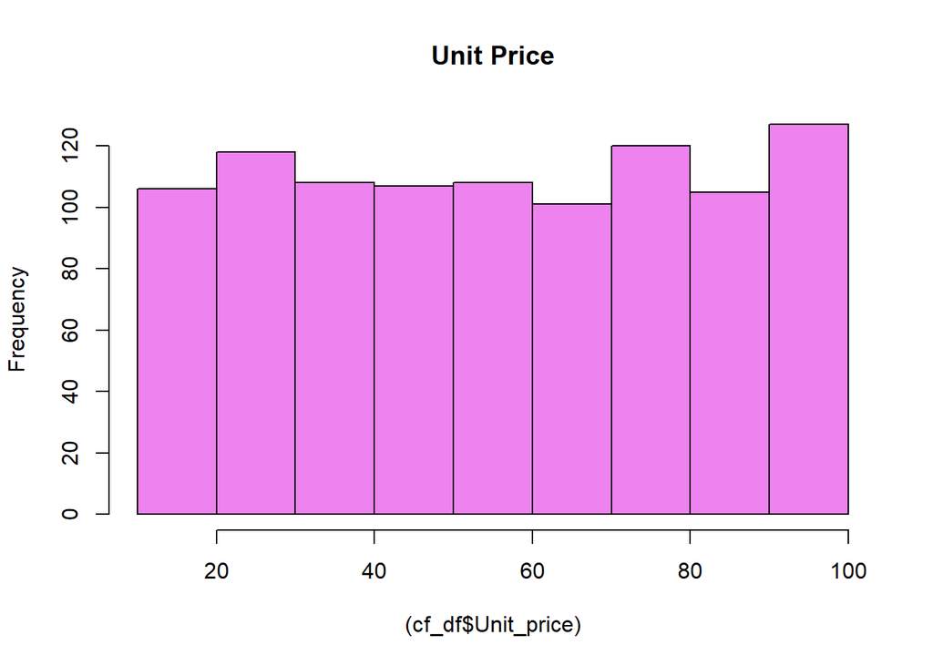

```r
hist((cf_df$"Unit_price"), col = "Violet", main = "Unit Price")
```

## Range

### Unit Price

### Standard deviation

```r
sd.p <- sd(cf_df$Unit_price)
sd.p
```

```
## [1] 26.49463
```

### Variance

```r
var.p <- var(cf_df$Unit_price)
var.p
```

```
## [1] 701.9653
```

### Range

```r
range.p <- range(cf_df$Unit_price)
range.p
```

```
## [1] 10.08 99.96
```

### Skewness

```r
skew.p <- skewness(cf_df$Unit_price)
skew.p
```

```
## [1] 0.00705623
```

### Kurtosis

```r
kurt.p <- kurtosis(cf_df$Unit_price)
kurt.p
```

```
## [1] -1.222062
```

## Gross income

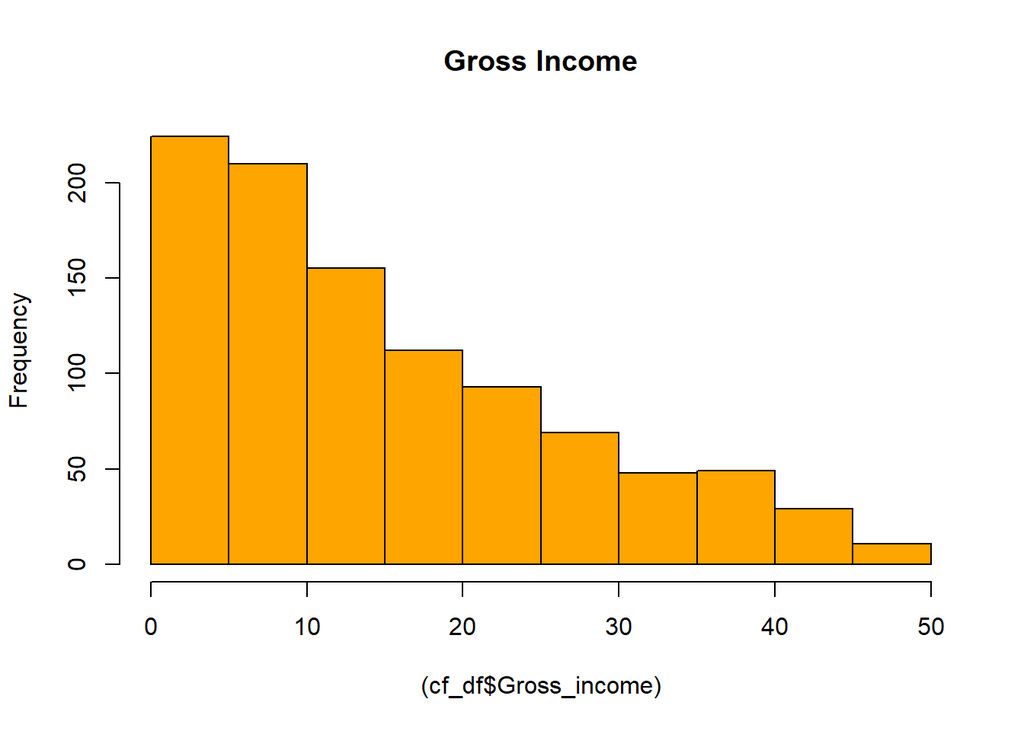

```r
hist((cf_df$"Gross_income"), col = "orange", main = "Gross Income")
```

### Standard Deviation

```r
sd.gi <- sd(cf_df$Gross_income)
sd.gi
```

```
## [1] 11.70883
```

### Variance

```r
var.gi <- var(cf_df$Gross_income)
var.gi
```

```
## [1] 137.0966
```

### Range

```r
range.gi <- range(cf_df$Gross_income)
range.gi
```

```
## [1]  0.5085 49.6500
```

### Skewness

```r
skew.gi <- skewness(cf_df$Gross_income)
skew.gi
```

```
## [1] 0.8898939
```

### Kurtosis

```r
kurt.gi <- kurtosis(cf_df$Gross_income)
kurt.gi
```

```
## [1] -0.09329206
```

## Quantity

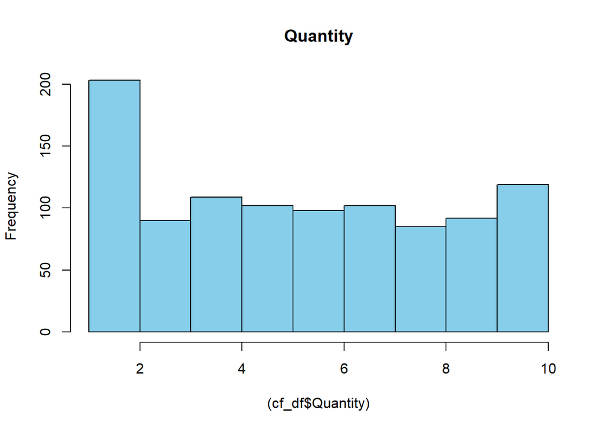

```r
hist((cf_df$"Quantity"), col = "skyblue", main = "Quantity")
```

### Standard Deviation

```r
sd.qty <- sd(cf_df$Quantity)
sd.qty
```

```
## [1] 2.923431
```

### Variance

```r
var.qty <- var(cf_df$Quantity)
var.qty
```

```
## [1] 8.546446
```

### Range

```r
range.qty <- range(cf_df$Quantity)
range.qty
```

```
## [1]  1 10
```

### Skewness

```r
skew.qty <- skewness(cf_df$Quantity)
skew.qty
```

```
## [1] 0.01290225
```

### Kurtosis

```r
kurt.qty <- kurtosis(cf_df$Quantity)
kurt.qty
```

```
## [1] -1.219039
```

## Cogs

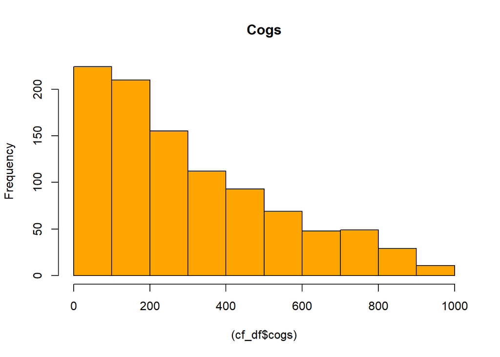

```r
hist((cf_df$"cogs"), col = "orange", main = "Cogs")
```

```r
sd.cogs <- sd(cf_df$cogs)
sd.cogs
```

```
## [1] 234.1765
```

```r
var.cogs <- var(cf_df$cogs)
var.cogs
```

```
## [1] 54838.64
```

```r
range.cogs <- range(cf_df$cogs)
range.cogs
```

```
## [1]  10.17 993.00
```

```r
skew.cogs <- skewness(cf_df$cogs)
skew.cogs
```

```
## [1] 0.8898939
```

```r
kurt.cogs <- kurtosis(cf_df$cogs)
kurt.cogs
```

```
## [1] -0.09329206
```

## Total

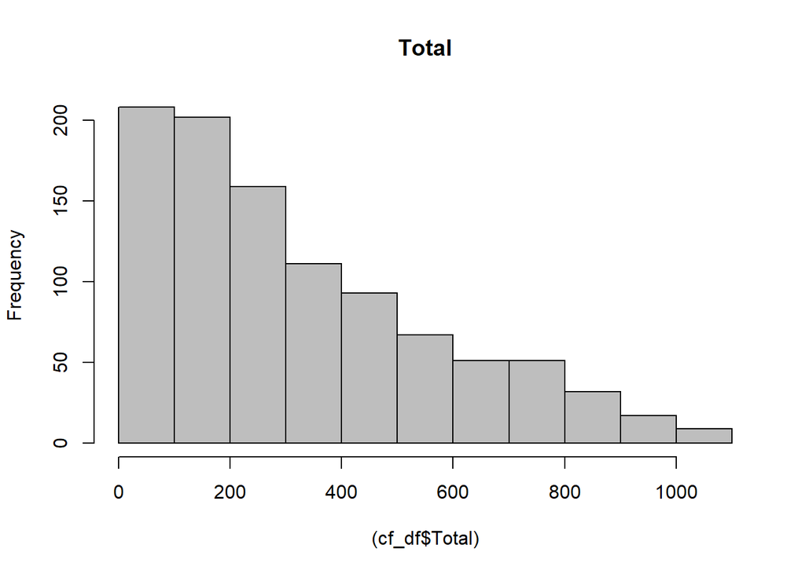

```r
hist((cf_df$"Total"), col = "grey", main = "Total")
```

```r
sd.total <- sd(cf_df$Total)
sd.total
```

```
## [1] 245.8853
```

```r
var.total <- var(cf_df$Total)
var.total
```

```
## [1] 60459.6
```

```r
range.total <- range(cf_df$Total)
range.total
```

```
## [1]   10.6785 1042.6500
```

```r
skew.total <- skewness(cf_df$Total)
skew.total
```

```
## [1] 0.8898939
```

```r
kurt.total <- kurtosis(cf_df$Total)
kurt.total
```

```
## [1] -0.09329206
```

## Rating

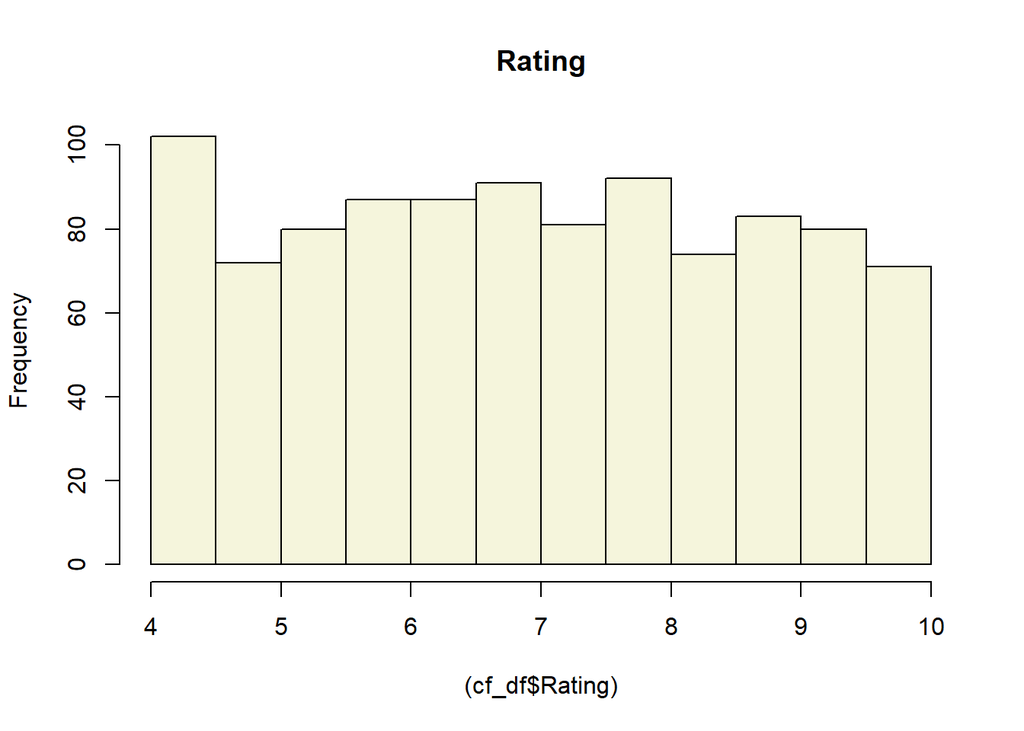

```r
hist((cf_df$"Rating"), col = "beige", main = "Rating")
```

```r
sd.r <- sd(cf_df$Rating)
sd.r
```

```
## [1] 1.71858
```

```r
var.r <- var(cf_df$Rating)
var.r
```

```
## [1] 2.953518
```

```r
range.r <- range(cf_df$Rating)
range.r
```

```
## [1]  4 10
```

```r
skew.r <- skewness(cf_df$Rating)
skew.r
```

```
## [1] 0.008982638
```

```r
kurt.r <- kurtosis(cf_df$Rating)
kurt.r
```

```
## [1] -1.155525
```

# Barplots

### Branches

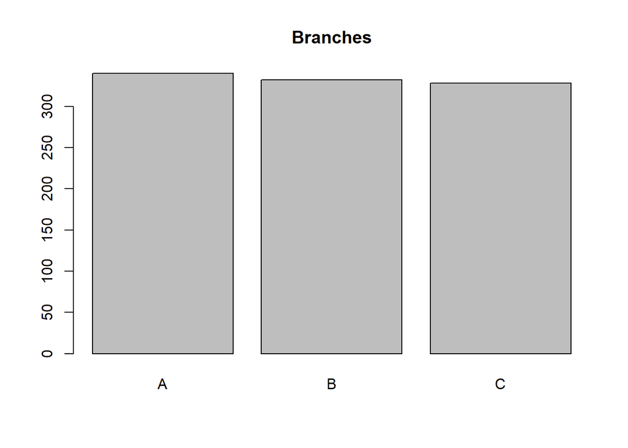

```r
barplot(table(cf_df$Branch), main = "Branches")
```

OBSERVATION

A has most activity to B and C though there is very little difference between them.

### Customer Type

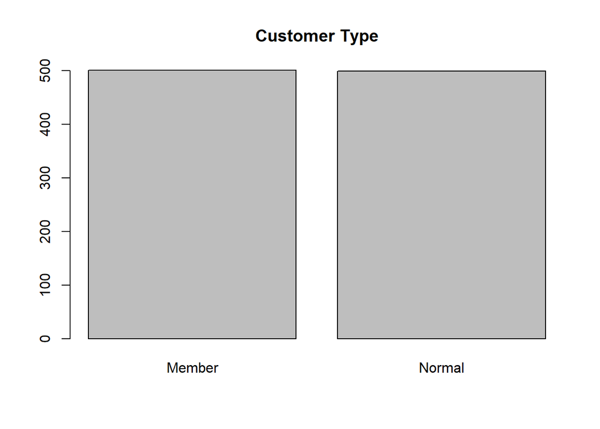

```r
barplot(table(cf_df$Customer_type), main = "Customer Type")
```

OBSERVATION Transaction between members and non-members are equal.

### Gender

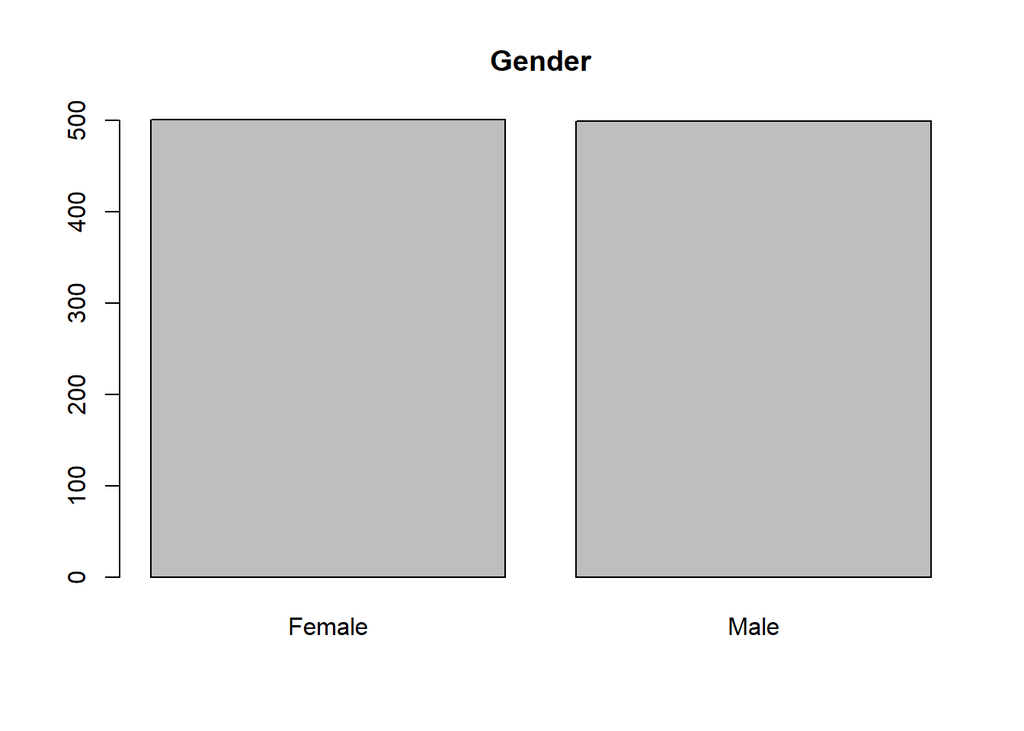

```r
barplot(table(cf_df$Gender), main = "Gender")
```

OBSERVATION No match difference between genders

### Product line

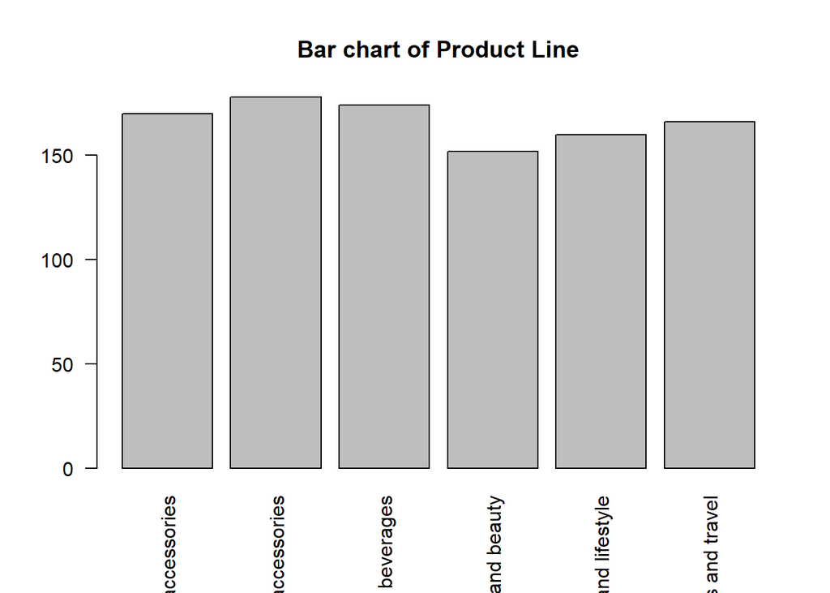

```r
barplot(table(cf_df$Product_line), main = "Bar chart of Product Line", las=2)
```

### Payment

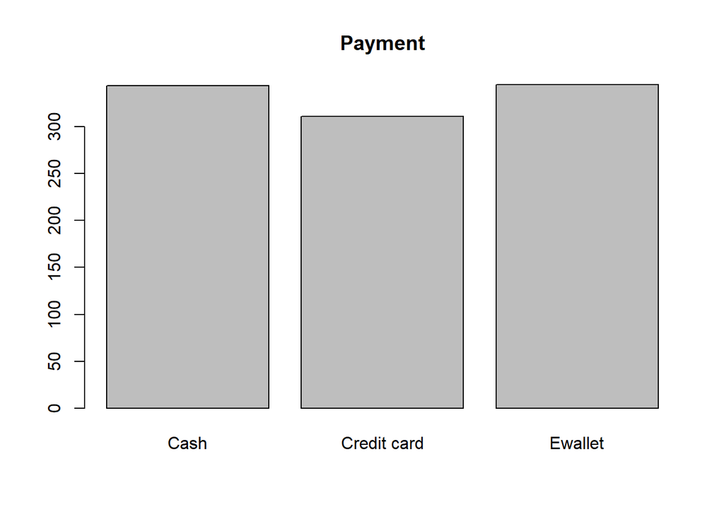

```r
barplot(table(cf_df$Payment), main = "Payment")
```

OBSERVATION

Most clients prefer using cash and Ewallet for payment transaction

**Bivariate Analysis** ## Lets create a new dataframe with numerical data variables

```r
Unit_price<- cf_df$Unit_price
Gross_income<-cf_df$Gross_income
cogs<-cf_df$cogs
Total<-cf_df$Total
Rating<-cf_df$Rating
num_data <- data.frame(Unit_price, Gross_income, cogs, Total, Rating)
```

## Lets preview our dataset

```r
head(num_data)
```

```
##   Unit_price Gross_income   cogs    Total Rating
## 1      74.69      26.1415 522.83 548.9715    9.1
## 2      15.28       3.8200  76.40  80.2200    9.6
## 3      46.33      16.2155 324.31 340.5255    7.4
## 4      58.22      23.2880 465.76 489.0480    8.4
## 5      86.31      30.2085 604.17 634.3785    5.3
## 6      85.39      29.8865 597.73 627.6165    4.1
```

# CORRELATION

Correlation is a statistical technique that can show whether and how strongly pairs of variables are related.

## Lets calculate correlation matrix

```r
corr <- cor(num_data)
head(corr)
```

```
##                Unit_price Gross_income       cogs      Total       Rating
## Unit_price    1.000000000    0.6339621  0.6339621  0.6339621 -0.008777507
## Gross_income  0.633962089    1.0000000  1.0000000  1.0000000 -0.036441705
## cogs          0.633962089    1.0000000  1.0000000  1.0000000 -0.036441705
## Total         0.633962089    1.0000000  1.0000000  1.0000000 -0.036441705
## Rating       -0.008777507   -0.0364417 -0.0364417 -0.0364417  1.000000000
```

## Lets plot the correlation matrix

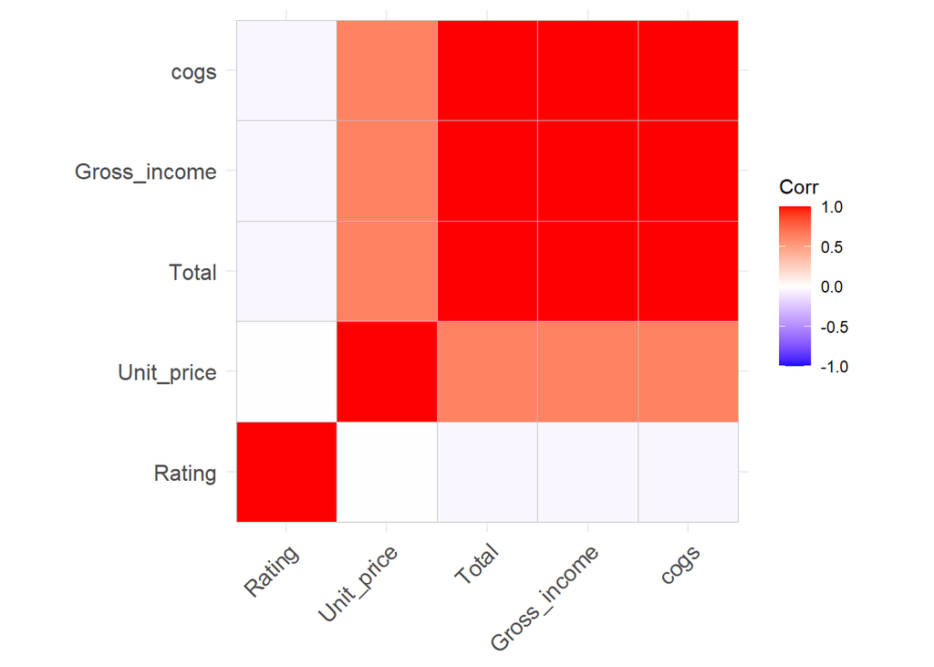

```r
ggcorrplot(corr,hc.order = TRUE)
```

OBSERVATION

There was a problem, We observe that most of the variables are perfectly correlated which is problematic in modelling hence the need for feature extraction or feature selection.

## Scatterplot

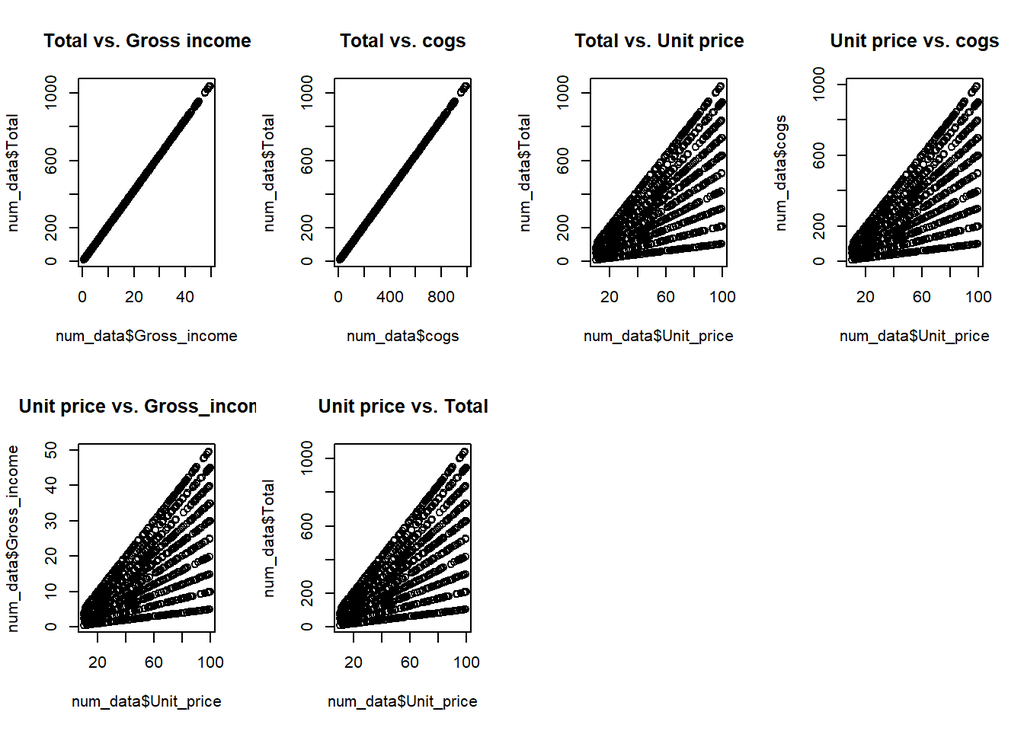

```r
par(mfrow=c(2,4))
plot(num_data$Gross_income,num_data$Total, main="Total vs. Gross income")
plot(num_data$cogs, num_data$Total, main="Total vs. cogs")
plot(num_data$Unit_price, num_data$Total, main="Total vs. Unit price")
plot(num_data$Unit_price,num_data$cogs, main="Unit price vs. cogs")
plot(num_data$Unit_price,num_data$Gross_income, main="Unit price vs. Gross_income")
plot(num_data$Unit_price,num_data$Total, main="Unit price vs. Total")
```

**## 7. IMPLEMENTING THE SOLUTION**

**PRINCIPAL COMPONENT ANALYSIS**

### Selecting the numerical data

```r
cf_df_num <- select_if(cf_df,is.numeric)
str(cf_df_num)
```

```
## 'data.frame':    1000 obs. of  6 variables:
##  $ Unit_price  : num  74.7 15.3 46.3 58.2 86.3 ...
##  $ Quantity    : int  7 5 7 8 7 7 6 10 2 3 ...
##  $ cogs        : num  522.8 76.4 324.3 465.8 604.2 ...
##  $ Gross_income: num  26.14 3.82 16.22 23.29 30.21 ...
##  $ Rating      : num  9.1 9.6 7.4 8.4 5.3 4.1 5.8 8 7.2 5.9 ...
##  $ Total       : num  549 80.2 340.5 489 634.4 ...
```

```r
ef.pca <- prcomp(cf_df_num, center = FALSE, scale. = TRUE)
summary(ef.pca)
```

```
## Importance of components:
##                           PC1     PC2     PC3     PC4       PC5       PC6
## Standard deviation     2.3249 0.60849 0.44308 0.16806 3.184e-16 1.283e-16
## Proportion of Variance 0.9009 0.06171 0.03272 0.00471 0.000e+00 0.000e+00
## Cumulative Proportion  0.9009 0.96257 0.99529 1.00000 1.000e+00 1.000e+00
```

### Lets look at our PCA object using the str function

```r
str(ef.pca)
```

```
## List of 5
##  $ sdev    : num [1:6] 2.32 6.08e-01 4.43e-01 1.68e-01 3.18e-16 ...
##  $ rotation: num [1:6, 1:6] -0.402 -0.405 -0.421 -0.421 -0.379 ...
##   ..- attr(*, "dimnames")=List of 2
##   .. ..$ : chr [1:6] "Unit_price" "Quantity" "cogs" "Gross_income" ...
##   .. ..$ : chr [1:6] "PC1" "PC2" "PC3" "PC4" ...
##  $ center  : logi FALSE
##  $ scale   : Named num [1:6] 61.68 6.24 386.71 19.34 7.18 ...
##   ..- attr(*, "names")= chr [1:6] "Unit_price" "Quantity" "cogs" "Gross_income" ...
##  $ x       : num [1:1000, 1:6] -3.13 -1.18 -2.2 -2.86 -3.27 ...
##   ..- attr(*, "dimnames")=List of 2
##   .. ..$ : NULL
##   .. ..$ : chr [1:6] "PC1" "PC2" "PC3" "PC4" ...
##  - attr(*, "class")= chr "prcomp"
```

## Lets now plot our PCA

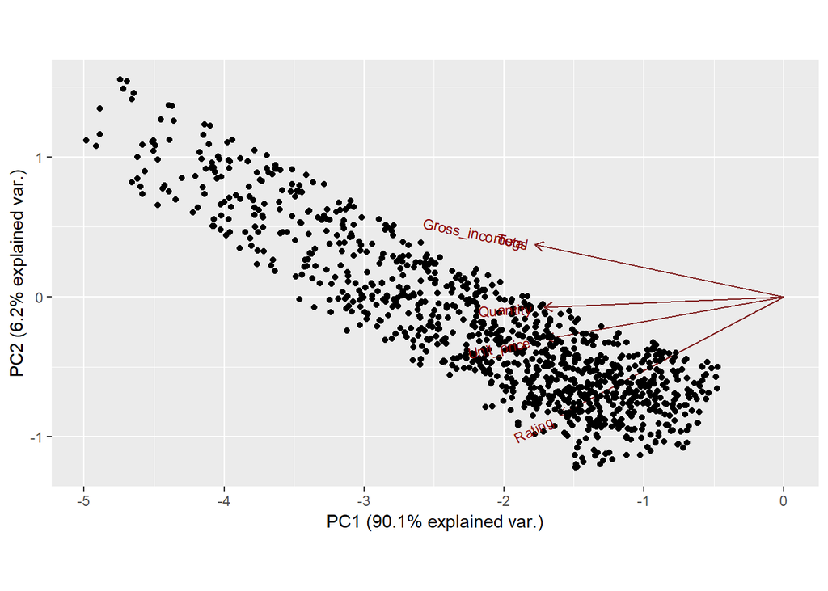

```r
set.seed(123)
ggbiplot(ef.pca, labels=rownames(ef.pca),ellipse = TRUE,obs.scale=1,var.scale=1)
```

OBSERVATION Our plotting is not so clear we will need to see the number of components that contribute more to PC1

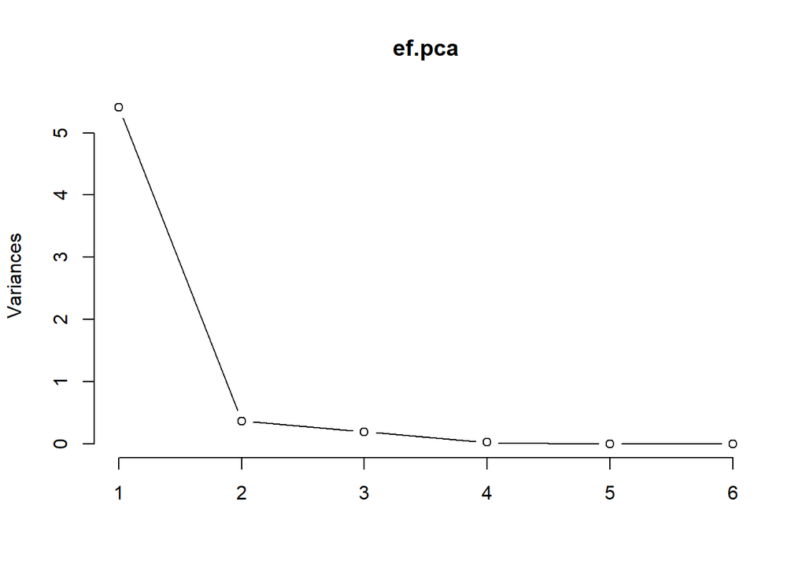

```r
plot(ef.pca, type="l")
```

## We can also ggbiplot to plt our pca

```r
library(ggbiplot)
```

# Adding more detail to the plot, we provide arguments rownames aslabels

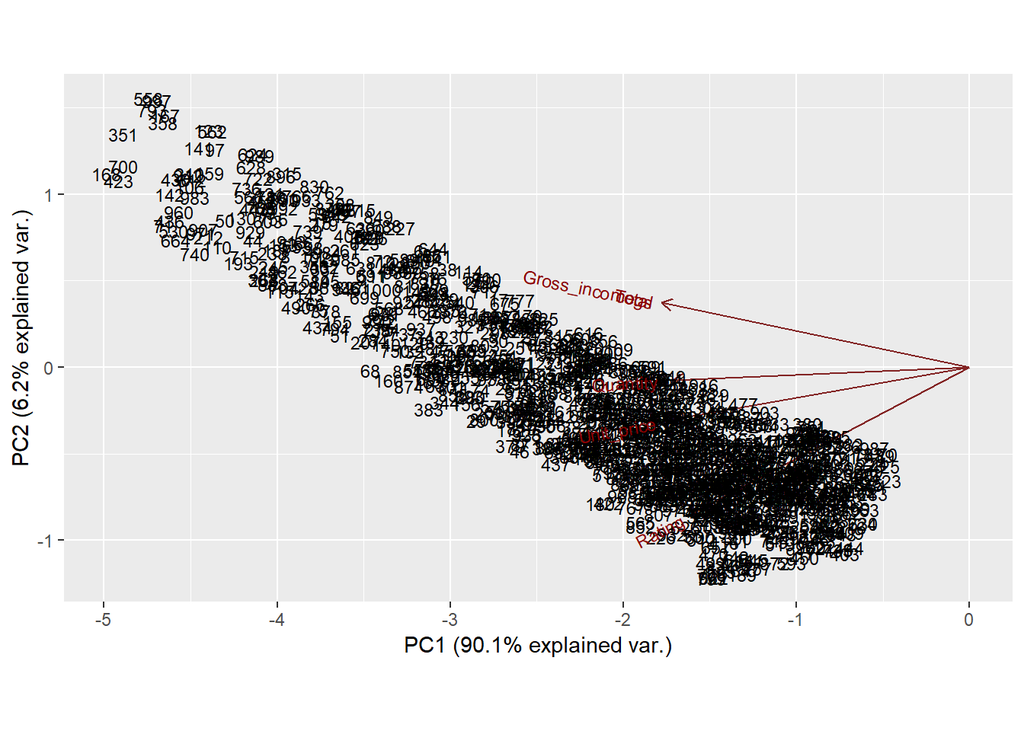

```r
ggbiplot(ef.pca, labels=rownames(cf_df), obs.scale = 1, var.scale
= 1)
```

# Challenging our solution

## t-SNE

## Lets reload our data set calling it train

```r
train <- read.csv(url("http://bit.ly/CarreFourDataset"))
```

# Loading our t_SNE library

```r
library(Rtsne)
```

# Curating the database for analysis

```r
Quantity <- cf_df$Quantity
cf_df$Quantity <-as.factor(cf_df$Quantity)
```

# For plotting

```r
colors = rainbow(length(unique(cf_df$Quantity)))
names(colors) = unique(cf_df$Quantity)
```

Executing our algorithm # Executing the algorithm on curated data #

```r
tsne <- Rtsne(train[,-1], dims = 2, perplexity=30, verbose=TRUE,
max_iter = 500)
```

```
## Performing PCA
## Read the 1000 x 50 data matrix successfully!
## OpenMP is working. 1 threads.
## Using no_dims = 2, perplexity = 30.000000, and theta = 0.500000
## Computing input similarities...
## Building tree...
## Done in 0.43 seconds (sparsity = 0.101258)!
## Learning embedding...
## Iteration 50: error is 59.245457 (50 iterations in 0.24 seconds)
## Iteration 100: error is 52.491480 (50 iterations in 0.28 seconds)
## Iteration 150: error is 51.533072 (50 iterations in 0.28 seconds)
## Iteration 200: error is 51.299541 (50 iterations in 0.26 seconds)
## Iteration 250: error is 51.304256 (50 iterations in 0.30 seconds)
## Iteration 300: error is 0.577032 (50 iterations in 0.28 seconds)
## Iteration 350: error is 0.409002 (50 iterations in 0.28 seconds)
## Iteration 400: error is 0.375627 (50 iterations in 0.27 seconds)
## Iteration 450: error is 0.361205 (50 iterations in 0.29 seconds)
## Iteration 500: error is 0.349271 (50 iterations in 0.29 seconds)
## Fitting performed in 2.78 seconds.
```

# Getting the duration of execution

```r
exeTimeTsne <- system.time(Rtsne(train[,-1], dims = 2, perplexity=30,
verbose=TRUE, max_iter = 500))
```

```
## Performing PCA
## Read the 1000 x 50 data matrix successfully!
## OpenMP is working. 1 threads.
## Using no_dims = 2, perplexity = 30.000000, and theta = 0.500000
## Computing input similarities...
## Building tree...
## Done in 0.41 seconds (sparsity = 0.101258)!
## Learning embedding...
## Iteration 50: error is 59.108724 (50 iterations in 0.30 seconds)
## Iteration 100: error is 51.436403 (50 iterations in 0.27 seconds)
## Iteration 150: error is 50.262878 (50 iterations in 0.28 seconds)
## Iteration 200: error is 49.793063 (50 iterations in 0.28 seconds)
## Iteration 250: error is 49.560881 (50 iterations in 0.30 seconds)
## Iteration 300: error is 0.567035 (50 iterations in 0.27 seconds)
## Iteration 350: error is 0.394019 (50 iterations in 0.32 seconds)
## Iteration 400: error is 0.344700 (50 iterations in 0.26 seconds)
## Iteration 450: error is 0.327148 (50 iterations in 0.33 seconds)
## Iteration 500: error is 0.316181 (50 iterations in 0.32 seconds)
## Fitting performed in 2.92 seconds.
```

Ploting the graph # Plotting our graph and closely examining the graph #

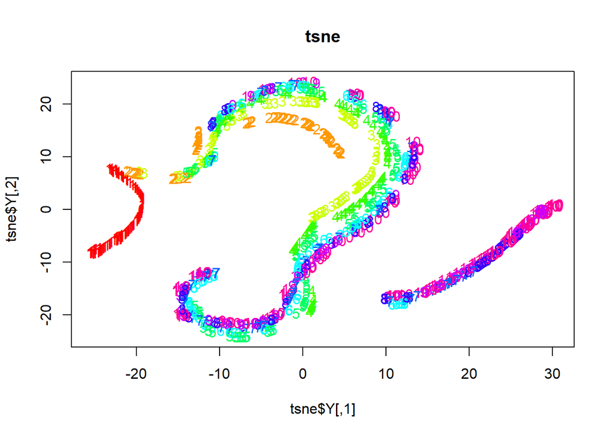

```r
plot(tsne$Y, t='n', main="tsne")
text(tsne$Y, labels=cf_df$Quantity, col=colors[train$Quantity])
```

# Feature Selection

### Calculating the correlation matrix

```r
corrmatrix <- cor(num_data)
```

### Find attributes that are highly correlated

```r
highcorr <- findCorrelation(corrmatrix, cutoff=0.75)
```

### Highly correlated attributes

```r
highcorr
```

```
## [1] 2 3
```

```r
names(num_data[highcorr])
```

```
## [1] "Gross_income" "cogs"
```

### Removing Redundant Features

```r
num_data_clean <- num_data[-highcorr]
```

### Performing our graphical comparison

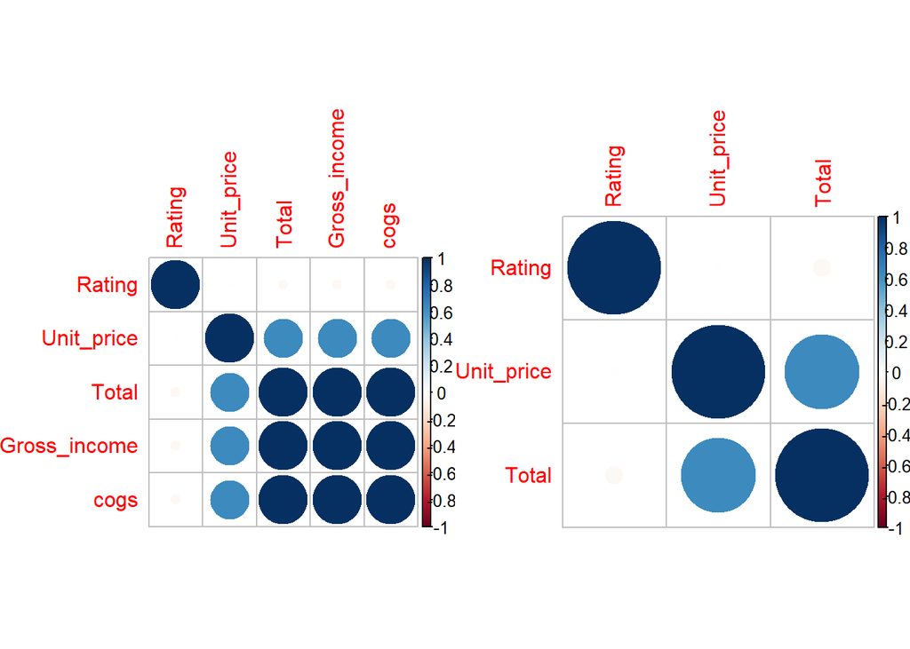

```r
par(mfrow = c(1, 2))
corrplot(corrmatrix, order = "hclust")
corrplot(cor(num_data_clean), order = "hclust")
```

OBSERVATION

Removing highly correlated variables result to less correlated variables. Hence the selected features are Unit_Price, Total and Rating. There are no more highly correlated variables.